# Assignment 1

```r
library(tidyverse)
library(readr)
```

### Question) SCN2A mutation- VARIANT_CLASS중 SNV의 Consequence 빈도

# 1. Load Data

```r
d = read.delim('table.scn2a.vep_20190916.filtered.txt', sep = '' , header = T)
```

# 2. Plot

In this data, we can classify SCN2A patients by ‘VARIANT_CLASS’(such as ‘deletion’, ‘indel’, ‘insertion’, ‘SNV’, ‘substitution’). Also we can classify them by ‘Consequence’(such as ‘frameshift_variant’, ‘inframe_deletion’, ‘inframe_insertion’, ‘missense_variant’, ‘missense_variant,splice_region_variant’, ‘stop_gained’, ‘stop_lost’, ‘synonymous_variant’). Using this SCN2A data, we would like to see if there is a connection between the ‘VARIANT_CLASS’ and the ‘Consequence’, and if so, see how it looks.

```r
#Check the column "Consequence", "VARIANT_CLASS" by using the function 'table()'
table(d$Consequence, d$VARIANT_CLASS)
```

```
                                         deletion indel insertion SNV substitution
  frameshift_variant                            0     4         8   0            0
  inframe_deletion                              2     0         0   0            0
  inframe_insertion                             0     0         4   0            0
  missense_variant                              0     0         0 757            1
  missense_variant,splice_region_variant        0     0         0  13            0
  stop_gained                                   0     0         0  28            0
  stop_lost                                     0     0         0   1            0
  synonymous_variant                            0     0         0 430            0
```

Actually, when we use `table()`, we can see the ‘missense_variant’ in ‘SNV’ is the highest. In particular, since ‘SNV’ accounts for about about 98% of the total, it seems inappropriate to make a plot by organizing the rest into items such as ‘SNV’. Therefore, we would make a plot by limiting ‘SNV’ among ‘VARIANT_CLASS’.

[output not shown]

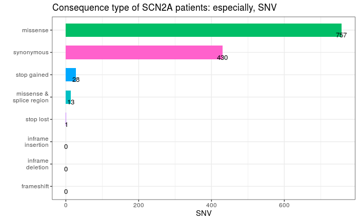

```r
#Make a data about "SNV" by using tidyverse
D1 <- d %>% filter(grepl("SNV",VARIANT_CLASS)==TRUE) %>% select(Consequence) %>% group_by(Consequence) %>% count()

#Because we don't have "frameshift_variant","inframe_deletion","inframe_insertion" in "SNV" type, we might get the graph with only 5 bar. To compare more corretly, make a new data.frame.
d_plus <- c("frameshift_variant","inframe_deletion","inframe_insertion")
d_plus__ <- data.frame(Consequence = as.factor(d_plus), n = 0)

#Add new data.frame to the first data and draw a plot
bind_rows(D1, d_plus__) %>% complete(fill=list(n=0)) %>%
  ggplot(aes(x=reorder(Consequence, n), y = n, fill=Consequence))+
  geom_bar(stat="identity", width=.6)+
  geom_text(aes(label=n), vjust=1.6, size=3.5)+
  scale_x_discrete(labels=c("missense_variant"="missense","synonymous_variant"="synonymous","stop_gained"="stop gained","missense_variant,splice_region_variant"="missense &\nsplice region","stop_lost"="stop lost","inframe_insertion"="inframe\ninsertion","inframe_deletion"="inframe\ndeletion","frameshift_variant"="frameshift"))+
  guides(fill=FALSE)+
  theme_minimal()+
  coord_flip()+
  xlab("")+
  ylab("SNV")+
  theme_bw()+
  ggtitle("Consequence type of SCN2A patients: especially, SNV")
```

# 3. Explanation

Define the words we saw above first:

deletion: The point at which one or more contiguous nucleotides were excised.

indel: an insertion or deletion of bases in the genome of an organism.

insertion: The sequence of one or more nucleotides added between two adjacent nucleotides in the sequence.

SNV: SNVs are single nucleotide positions in genomic DNA at which different sequence alternatives exist.

substitution: A sequence alteration where the length of the change in the variant is the same as that of the reference.

missense variant(‘missense’ in plot) : A genetic alteration in which a single base pair substitution alters the genetic code in a way that produces an amino acid that is different from the usual amino acid at that position. Some missense variants (or mutations) will alter the function of the protein. Also called missense mutation.

synonymous variant(‘synonymous’ in plot) : A sequence variant where there is no resulting change to the encoded amino acid.

frameshift variant(‘frameshift’ in plot) :A sequence variant which causes a disruption of the translational reading frame, because the number of nucleotides inserted or deleted is not a multiple of three.

inframe deletion : An inframe non synonymous variant that deletes bases from the coding sequence.

inframe insertion : An inframe non synonymous variant that inserts bases into in the coding sequence.

stop lost : A sequence variant where at least one base of the terminator codon (stop) is changed, resulting in an elongated transcript.

stop gained : A sequence variant whereby at least one base of a codon is changed, resulting in a premature stop codon, leading to a shortened polypeptide.

splice region variant : A sequence variant in which a change has occurred within the region of the splice site, either within 1-3 bases of the exon or 3-8 bases of the intron.